# PSY6422 Project

Amy Keay

2025-12-01

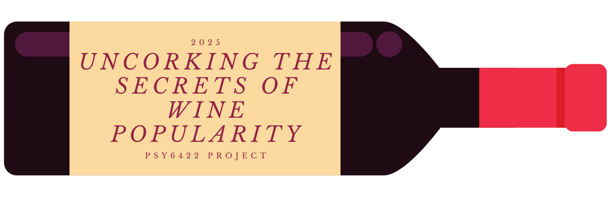

# Data Origins

Data was obtained from [“Data Is Plural”](https://www.google.com/url?sa=t&source=web&rct=j&opi=89978449&url=https://www.data-is-plural.com/&ved=2ahUKEwjF3KWz5YiRAxUEVkEAHVTHKrYQFnoECCgQAQ&usg=AOvVaw21waTAlcdAq2a68pmQCcr2) a newsletter of useful and curious datasets published by Jeremy Singer-Vine. There have been 400 editions, dating from October 21, 2015 to August 27, 2025.

The dataset used for this project, [“X-Wines Dataset”](https://github.com/rogerioxavier/X-Wines) by Rogério Xavier de Azambuja et al., comprises Wines and Wine Ratings of 100,000+ wines produced in 60+ countries and is publicly accessible on GitHub.The data was collected and standardised from “wine-specialised websites,” winery websites, and other sources and indicates each wine’s name, type, grape varieties, alcohol level, acidity level, country, region, winery and vintages. It also includes ratings on a 1-to-5 scale of those wines by 1 million anonymised users.

# Research Questions

The first aim of this project is to determine whether certain characteristics of wine including wine type, ABV, body and acidity, have an effect on popularity (operationalised on a 1-to-5 scale, higher ratings represent more popular wine).

# Data Preparation

## Loading Packages

```r
library(tidyverse)
library(ggplot2)
library(dplyr)
```

## Importing Data

```r
#Import Wine Information Data
Wine_Info <- read_csv("Wine_Info.csv")
#Import Wine Ratings Data
Wine_Ratings <- read_csv("Wine_Ratings.csv")
```

```r
#here is the first few rows of raw data for Wine Information Data
head(Wine_Info, 10)
```

```
## # A tibble: 10 × 17
##    WineID WineName    Type  Elaborate Grapes Harmonize   ABV Body  Acidity Code
##     <dbl> <chr>       <chr> <chr>     <chr>  <chr>     <dbl> <chr> <chr>   <chr>
##  1 100062 Origem Mer… Red   Varietal… ['Mer… ['Beef',…  13   Full… Medium  BR
##  2 100191 Reserva Ch… White Varietal… ['Cha… ['Rich F…  13   Medi… Medium  BR
##  3 101847 Dona Anton… Dess… Assembla… ['Tou… ['Appeti…  20   Very… High    PT
##  4 102055 Fine Ruby … Dess… Assembla… ['Tin… ['Sweet …  19.5 Very… Medium  PT
##  5 102079 Maré Alta   White Assembla… ['Lou… ['Fish',…  10   Very… High    PT
##  6 102645 Terras de … Spar… Assembla… ['Lou… ['Appeti…  11.5 Medi… Medium  PT
##  7 102902 Pátria Ale… Red   Assembla… ['Ali… ['Beef',…  14.5 Full… Medium  PT
##  8 103003 Além do Ri… White Assembla… ['Mal… ['Pasta'…   9.5 Medi… High    PT
##  9 103070 Calda Bord… Red   Assembla… ['Cab… ['Beef',…  14   Full… Medium  PT
## 10 103433 Regional T… Red   Assembla… ['Ara… ['Beef',…  13   Full… Medium  PT
## # ℹ 7 more variables: Country <chr>, RegionID <dbl>, RegionName <chr>,
## #   WineryID <dbl>, WineryName <chr>, Website <chr>, Vintages <chr>
```

```r
#here is the first few rows of raw data for Wine Ratings Data
head(Wine_Ratings, 10)
```

```
## # A tibble: 10 × 6
##    RatingID  UserID WineID Vintage Rating Date
##       <dbl>   <dbl>  <dbl> <chr>    <dbl> <dttm>
##  1     3211 1209683 111478 1959       4.5 2016-08-08 00:50:22
##  2    27878 1209980 111478 1975       4   2018-08-12 17:09:39
##  3    31227 1258705 111478 1975       5   2014-11-16 19:52:38
##  4    41946 1139706 111478 1979       5   2014-12-22 02:30:15
##  5    61700 1240747 111478 1982       4.5 2019-10-21 02:01:10
##  6    64438 1123010 111478 1982       4   2021-01-09 15:58:00
##  7    64751 1003868 111478 1982       4   2018-03-30 09:12:01
##  8    73066 1224698 111478 1983       3.5 2016-12-26 07:28:24
##  9    97040 1265698 132977 1987       4.5 2021-11-28 13:38:21
## 10   101042 1218495 111478 1988       5   2017-10-21 12:55:02
```

## Cleaning Data

This is the process of cleaning my data for the Wine Information Dataset.

```r
#select columns of raw data to keep from Wine Information Data
Wine_Info <- Wine_Info %>%
  select(WineID, WineName, Type, ABV, Body, Acidity, Country, RegionName, Vintages)
```

This is the process of cleaning my data for the Wine Ratings Dataset.

```r
#select columns of raw data to keep from Wine Ratings Data
Wine_Ratings <- Wine_Ratings %>%
  select(WineID, Vintage, Rating)

#sort columns of Wine Ratings Data in order of WineID
Wine_Ratings <- Wine_Ratings[order(Wine_Ratings$WineID), ]

#create overall wine rating for each Wine Name (WineID)
Wine_Overall <- Wine_Ratings %>%
  group_by(WineID) %>%
  summarise(overall_rating = mean(Rating, na.rm = TRUE)) %>%
  ungroup()
```

This is the process of merging the datasets so that I have a comprehensive dataset that includes wine information and an average rating for each individual wine in the dataset.

```r
#merge datasets to one including both Wine Information and Overall Wine Rating
Wine_Final <- Wine_Info %>%
  left_join(Wine_Overall, by = "WineID")
```